# 1期ゼミ資料 - 1 イントロダクション

Published

2023/04/11

[スライド](https://tomo-sakuma.github.io/1st_semi/1期_slides/1_イントロ.html)

## 1.1 ゼミの説明

[figure not shown]

### 1.1.1 MCS

**マネジメント・コントロール・システム（MCS)**

企業が目的を達成するために従業員をコントロールする仕組み

- 従業員は
  - できるだけ辛い思いはしたくない
  - できるだけ高い給料は欲しい
  - 自分の部署の利益＞会社全体の利益
- 企業は
  1. 従業員の働きぶり（努力）を把握して
  2. 努力に報いる

  仕組みを通して，従業員の努力の方向を会社の目標に向かったものにして，なおかつ努力量を引き出したい

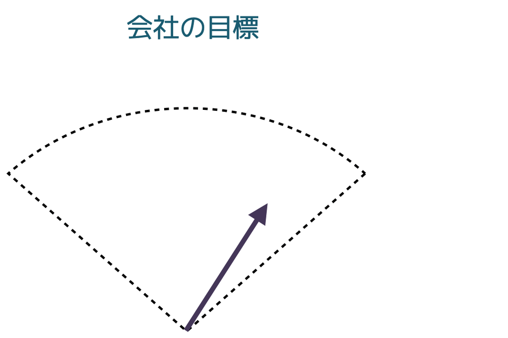

でも，マネジメントコントロールの仕組みを作って運用することは実際には難しい

- そもそも努力を直接測ることは難しい
- メインで使われる会計の数値は，そもそも別目的（財務会計目的）で作られている
- 顧客満足度などの会計以外の数値データもあるけれど財務的成果に結びつくかどうか検証するのは難しい
- 予算などの仕組みは従業員の努力を測る目的以外でも使われるので，意図しない従業員の反応を生んでしまう事も

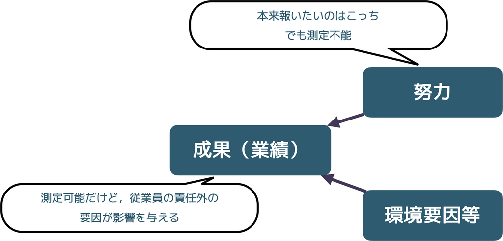

### 1.1.2 データ分析

マネジメントコントロールは，会社のデータを使う。

- 会計数値
- 顧客満足度
- 歩留率
- 回転率
- 市場シェア

[figure not shown]

これらのデータから，何かしらの判断をしたり，従業員の働きぶりを評価したりする。

- 顧客満足度は財務的成果につながっている？
- 営業担当者のどんな行動が成果につながりやすい？
- どんな店長が「優秀」？

これらの疑問に答えるためには，結構高度なデータ分析スキルが求められる。

### 1.1.3 「MCS × データ分析」

- 会社にはどんなデータがあって，それぞれが何を表しているのか？
- 従業員をコントロールするためにどんな仕組みが必要なのか？

といったMCSの知識と

- データ同士にどんな関係があるのか？
- MCSの仕組みはうまくいっているのか？

といったことを検証するデータ分析のスキルを組み合わせて使えるようになって欲しいなぁ。。。

## 1.2 進め方

できたら…

- 会計のテキスト 40分
- Rのテキスト 40分
- 面白い会社，取組の紹介 10分

[figure not shown]

### 1.2.1 教科書

**「現場が動き出す会計」**

伊丹敬之 ・青木康晴 (2016)

日経BPマーケティング(日本経済新聞出版)

「**Rによる実証分析 (第2版)**」

星野匡郎・田中久稔・北川梨津 (2023)

オーム社

[figure not shown]

[figure not shown]

### 1.2.2 皆さんの作業

#### 発表者

- 発表資料を作ってきて，**前日までに**アップロードしてください。
- 発表時間の目安は**30分**
- 読んだことのない方もわかるように
- ほかの教科書や，その章で扱われている内容の専門書等，自分で探してきた事例などで必要に応じて補足してください
- スライド形式を基本としますが，場合によってはノートブック形式などでも
  - PowerPoint
  - Keynote
  - Google Slides
  - Quarto (Rの方の時おすすめ）

  ちなみにこのスライドはQuartoで作っています
- Rの本では，**コードとその実行結果を実演**してほしいです

#### 発表者以外

- 該当する章に目を通してきてください
- わからないところがあっても事前に調べてくる必要はありません（当日質問してください）
- 自分で読んできて，発表者の発表内容を聞いて分からなかったことや，疑問に思ったことを質問・コメントしてください。
- Rの方は自分のパソコンでもコードを動かしてもらいたいので，パソコンは持ってきてください

[figure not shown]

#### 話題提供係

- ニュースや雑誌記事，自分の周りで起こったこと等，経営学に関連する何かを見つけてきて話してください。
- 3分程度
- どんな内容で，どんなところが興味深かったかを教えてください。
- 必要に応じて記事のリンクや資料など用意してください。

[figure not shown]

## 1.3 ゼミで使うツールについて

**Zulip**

ゼミ全体やグループ研究等の際の連絡用

**Notion**

- ゼミの決まりやツールの使い方などをwiki的に活用
- グループ研究や卒論の置き場としても
- 場合によってはグループ研究のアイデアメモにも？

**google drive**

発表資料の共有や，共同編集用

**RとRstudio**

統計分析とその結果のレポート。場合によってはスライドや卒論も書けます。

[figure not shown]

[figure not shown]

[figure not shown]

[figure not shown]

### 1.3.1 Zulip

- チャットアプリ。連絡は基本これで
- グループチャットのstreamと個人間のやり取り用のprivateメッセージがある
  - 質問や意見などは基本的には適したサイズのstreamで
  - 個人的な事情を含む連絡はprivateメッセージで
- 発表ファイルとかは，google driveの適したフォルダに入れて，そのリンクをzulipに貼ってください

[figure not shown]

### 1.3.2 Notion

- しばらくは佐久間が更新してみます。
- 大学のアドレスで登録すると，有料プランをタダで使えますし，別に無料プランでも大丈夫です。
- zulipの使い方，notionの使い方，Rの使い方などをとりあえずまとめつつありますが，需要に応じて書き足していきます。

[figure not shown]

### 1.3.3 Google Drive

- クラウドストレージ
- 基本的に発表とかのファイル類はここに保存します
- グループで文書とかスライドを共同編集する時にも便利かも

[figure not shown]

### 1.3.4 RとRstudio

- 統計用言語とそれを使いやすくするなんか
- 詳しくは来週お話しします
- 分析だけでなく，結果のレポートも書けます
- なんなら，論文やスライドも作れます

[figure not shown]

## 1.4 発表の担当決め

次回（4/18）はRの使い方を説明するので，来週からです。

[スケジュールと内容](https://www.notion.so/9998dcf2234047eaad1cc89102dccdbc)

## 1.5 余談…

大学院のゼミもやってます。

- が，会計学領域は深刻な研究者不足です。
- 東京や京都に経営学研究科がない事もあり，経営学者は主に神戸と一橋という旧高等商業学校から輩出される傾向があります。
  - 研究者養成の使命

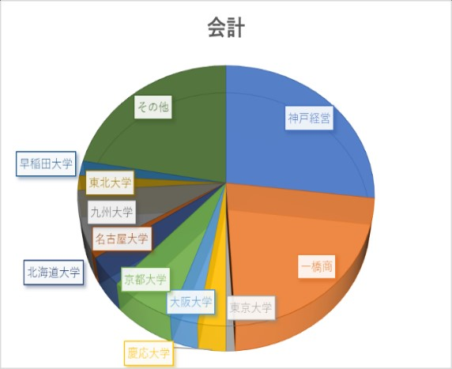

神戸大学経営学研究科から

- しかし，神戸と一橋でも会計学（特に佐久間の知っている管理会計）の大学院生はすごく減っています。
- 博士後期課程にいる大学院生（社会人大学院生を除く）は一橋は知る限り0，神戸は3程度
- 日本の学部→修士→アメリカの大学院のようなルートをとる学生もほとんどいない（2人知ってる）

### 1.5.1 進路面

#### **修士→就職**

- 一般企業
- 一部業界（戦略コンサル，専門コンサル，研究所等）は修士卒の方が有利？

#### **修士→博士→研究者**

- 経営学部・商学部，その他社会科学系，一部理科系学部

#### **修士→アメリカ等の大学院**

- アメリカの博士課程は，大学と雇用関係（**給料が出る**）
- トップスクールで生き残れたらトップスクールに就職できる
  - ビジネススクールなら初任給21万ドル程度？
- 終身雇用権を得る or 米国内外の大学に転職

### 1.5.2 職業面

- 研究者の仕事
  - 研究・教育・その他
- 勤務形態は基本的に裁量労働
  - 9時5時でスーツ着て出勤しなくても良い
  - 拘束時間は授業と会議？
- 研究は競技？
  - まだ誰もやっていないテーマを探す
  - 適切なデータを作ったり手に入れたりする
  - 論文にして審査を受ける
  - どのランクの論文雑誌にどんだけ載せたか？

[figure not shown]

- 日本の経営学，特に会計学は世界に遅れています
  - 日本の研究者で世界トップ3雑誌に載せた論文は0
    - 厳密にいうと1970年代に数本，ただしアメリカの大学院卒
  - 日本チャンピオンになるチャンスがあります
- 癖のある職業なので広くお勧めすることはしませんが「そんな選択肢もある」ということを知ってて欲しいです！

[figure not shown]